# FastReseg to detect and correct segmentation error in spatial transcriptome data

Lidan Wu

2025-12-06

This tutorial below shows how to apply functions in `FastReseg` to perform segmentation error detection and correction in spatial transcriptome data.

## FastReseg workflow diagram

`FastReseg` package processes spatial transcriptome data through 5 different modules and provides 3 wrapper functions for streamline processing of multi-FOV dataset to different exit points.

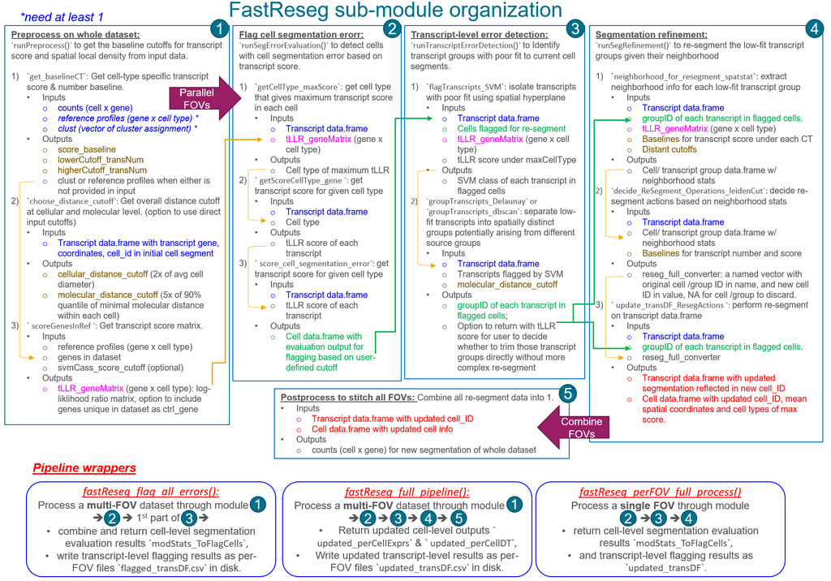

## Input data

The required inputs include:

- `counts`: a cell-by-gene counts matrix for entire dataset.
- `clust`: a vector of cluster assignments for each cell in `counts`; use `NULL` to automatically assign the cell cluster for each cell based on maximum transcript score of given the provided `refProfiles`.
- `refProfiles`: a gene-by-cluster matrix of cluster-specific expression profiles; default = `NULL` to use external cluster assignments.
- `transDF_fileInfo`: a data.frame with each row for each individual file of per-FOV transcript data.frame, columns include the file path of per FOV transcript data.frame file, annotation columns like `slide` and `fov` to be used as prefix when creating unique cell_ID across entire dataset.
  - when `NULL`, use the transcript data.frame `transcript_df` directly.

There must be at least one of the `clust` and `refProfiles` provided to run the `FastReseg` pipeline. All the spatial coordinates and distance are in the units of micron for consistency. Please refer to example data coming with the package to see how it looks like.

```r
# load example input data from package
library(FastReseg)

# get cell-by-gene `counts`
data("example_CellGeneExpr")
counts <- example_CellGeneExpr

# get cluster assignment `clust`
data("example_clust")
clust <- example_clust

# get cluster-specific reference profiles `refProfiles`
data("example_refProfiles")
refProfiles <- example_refProfiles

# create `transDF_fileInfo` for multiple per FOV transcript data.frame
# coordinates for each FOV, `stage_x` and `stage_y`, should have units in micron.
dataDir <- system.file("extdata", package = "FastReseg")
transDF_fileInfo <- data.frame(file_path = fs::path(dataDir,
                                                    c("Run4104_FOV001__complete_code_cell_target_call_coord.csv",
                                                      "Run4104_FOV002__complete_code_cell_target_call_coord.csv")),
                               slide = c(1, 1),
                               fov = c(1,2),
                               stage_X = 1000*c(5.13, -2.701),
                               stage_Y = 1000*c(-0.452, 0.081))
```

Here is an example of per-FOV transcript data.frame with necessary columns for:

- `target` for gene name;
- `x`, `y` and optional `z` for spatial coordinates of each transcript;
- `UMI_cellID` for cell ids of current cell segmentation and must be unique across all FOVs of the same dataset;
  - When not available, `prepare_perFOV_transDF()` function would use per-FOV unique `CellId` and the provided `prefix_colns = c('slide', 'fov')` to generate `UMI_cellID` that would be unique across the entire dataset. Pipeline wrappers, `fastReseg_flag_all_errors()` and `fastReseg_full_pipeline()`, would also generate unique cell ids in same manner for the multiple files listed in `transDF_fileInfo`.
- `UMI_transID`: transcript ids that are unique across the dataset;
  - By default, the `prepare_perFOV_transDF()` function and the 2 pipeline wrappers would use row index of transcript in each per-FOV transcript data.frame and `UMI_cellID` to create `UMI_transID` that would be unique across the entire dataset.

| UMI_transID | UMI_cellID | x | y | z | target | slide | fov | CellId |
| --- | --- | --- | --- | --- | --- | --- | --- | --- |
| t_1_2_10 | c_1_2_5 | 914.8070 | -7832.786 | 2.4 | HLA-DRA | 1 | 2 | 5 |
| t_1_2_100005 | c_1_2_1270 | 841.7000 | -8045.011 | 2.4 | HLA-E | 1 | 2 | 1270 |
| t_1_2_100006 | c_1_2_1270 | 844.4609 | -8045.006 | 2.4 | TWIST1 | 1 | 2 | 1270 |
| t_1_2_100007 | c_1_2_1286 | 878.1635 | -8045.002 | 2.4 | HLA-B | 1 | 2 | 1286 |
| t_1_2_10001 | c_1_2_201 | 1018.2337 | -7859.833 | 2.4 | S100A6 | 1 | 2 | 201 |
| t_1_2_100015 | c_1_2_1292 | 885.8180 | -8045.029 | 2.4 | HBB | 1 | 2 | 1292 |

As mentioned above, `FastReseg` package provides 2 pipeline wrappers for streamline multi-FOV processing and those wrapper would go through each per-FOV transcript data.frame listed in `transDF_fileInfo` and stitch all FOVs together to get data with coordinates in the global system as well as transcript and cell IDs unique across the entire dataset. When preparing the per-FOV data.frame outside the pipeline wrappers, one can read in each per-FOV file and process it with `prepare_perFOV_transDF()` function to get the unique IDs for cells and transcripts as well as converting the local coordinates in pixel for each FOV to a global coordinate in micron for entire dataset.

```r
#  process 1st file in the `transDF_fileInfo` entry
idx = 1
rawDF <- read.csv(transDF_fileInfo[idx, 'file_path'])

head(rawDF, n = 3L)
```

```
#>   fov seed_x seed_y         x        y z     std_x     std_y
#> 1   1  866.0 1250.5  865.9666 1250.467 1 0.1366284 0.1365927
#> 2   1 1026.8 1250.6 1026.7778 1250.656 1 0.1202107 0.1424117
#> 3   1 1008.0 1250.9 1008.0501 1250.933 1 0.1378334 0.1365927
#>   X95_perc_conf_int_x X95_perc_conf_int_y target target_idx Spot1_count
#> 1           0.2867654           0.2866904    AXL         70           1
#> 2           0.1848043           0.2189347   IL16        506           3
#> 3           0.2892946           0.2866905 S100A6        846           1
#>   Spot2_count Spot3_count Spot4_count target_call_observations
#> 1           2           2           1                        6
#> 2           2           3           1                        9
#> 3           2           2           1                        6
#>   target_count_per_feature random_call_probability possible_BC_count
#> 1                        1             0.002597012                 1
#> 2                        1             0.002597012                 1
#> 3                        1             0.010347653                 4
#>   spots_per_feature multicolor_spots_per_feature call_quality_score CellId
#> 1                 4                            0       0.0001604543   2932
#> 2                 4                            0       0.0019040769    864
#> 3                 5                            0       0.0001396453      0
#>   CellComp transcript_id
#> 1  Nuclear         11356
#> 2  Nuclear         11359
#> 3        0         11363
```

```r
transcript_df_all <- prepare_perFOV_transDF(each_transDF = rawDF,
                                            fov_centerLocs = unlist(transDF_fileInfo[idx, c('stage_X', 'stage_Y')]),
                                            prefix_vals = unlist(transDF_fileInfo[idx, c('slide', 'fov')]),
                                            pixel_size = 0.12, # micron per pixel
                                            zstep_size = 0.8, # micron per z step
                                            transID_coln = NULL, # use row index
                                            transGene_coln = 'target', # gene name
                                            cellID_coln = 'CellId', # cell label unique at FOV level
                                            spatLocs_colns = c('x', 'y', 'z'), # column names for spatial coordinates in pixel for each FOV
                                            invert_y = TRUE, # flip Y axis (default = TRUE) between local image coordinate and global stage coordinate
                                            extracellular_cellID = 0, # set this to the cell ID for extracellular transcript, use NULL if your data only contains intracellular transcripts
                                            drop_original = TRUE) # set to FALSE if want to have columns for original cell ID and spatial coordinates returned in the data.frame

str(transcript_df_all)
```

```
#> List of 2
#>  $ intraC:'data.frame':  151712 obs. of  6 variables:
#>   ..$ UMI_cellID : chr [1:151712] "c_1_1_2932" "c_1_1_864" "c_1_1_2923" "c_1_1_864" ...
#>   ..$ UMI_transID: chr [1:151712] "t_1_1_1" "t_1_1_2" "t_1_1_5" "t_1_1_6" ...
#>   ..$ target     : chr [1:151712] "AXL" "IL16" "HSP90AA1" "MZT2A" ...
#>   ..$ x          : num [1:151712] 5234 5253 5196 5252 5192 ...
#>   ..$ y          : num [1:151712] -602 -602 -602 -602 -602 ...
#>   ..$ z          : num [1:151712] 0.8 0.8 0.8 0.8 0.8 0.8 0.8 0.8 0.8 0.8 ...
#>  $ extraC:'data.frame':  110792 obs. of  6 variables:
#>   ..$ UMI_cellID : chr [1:110792] "c_1_1_0" "c_1_1_0" "c_1_1_0" "c_1_1_0" ...
#>   ..$ UMI_transID: chr [1:110792] "t_1_1_3" "t_1_1_4" "t_1_1_8" "t_1_1_10" ...
#>   ..$ target     : chr [1:110792] "S100A6" "IFI27" "HLA-A" "SOD2" ...
#>   ..$ x          : num [1:110792] 5251 5192 5306 5251 5269 ...
#>   ..$ y          : num [1:110792] -602 -602 -602 -602 -603 ...
#>   ..$ z          : num [1:110792] 0.8 0.8 0.8 0.8 0.8 0.8 0.8 0.8 0.8 0.8 ...
```

```r
## we would focus on intracellular transcripts for downstream segmentation error detection
transcript_df <- transcript_df_all[["intraC"]]
```

## Pipeline wrapper functions for streamline processing

For streamline processing of big dataset with multiple FOVs, one can use the pipeline wrapper functions provided in the `FastReseg` package without going through the individual steps that are discussed in later part of this tutorial. Those pipeline wrappers would preprocess at whole dataset level first to get appropriate cutoffs, and then perform segmentation evaluation and optional correction on each FOV, followed by combining per FOV data into one. Please refer to the manual of each pipeline wrapper for more details and to section Processing each FOV outside of core wrapper for excerpts of example outputs.

### Pipeline wraper for cell-level segmentation detection across multi-FOV dataset

A common use case of `FastReseg` is to evaluate the current cell segmentation of entire multi-FOV dataset and then identify the transcripts with poor goodness-of-fit to current cell and thus likely arsing from potential neighborhood contamination. And this could be done with `fastReseg_flag_all_errors()` function.

```r
flagAll_res <- fastReseg_flag_all_errors(
  counts = counts,
  clust = clust,
  refProfiles = NULL,

  # Similar to `runPreprocess()`, one can use `clust = NULL` if providing `refProfiles`

  transcript_df = NULL,
  transDF_fileInfo = transDF_fileInfo,
  filepath_coln = 'file_path',
  prefix_colns = c('slide','fov'),
  fovOffset_colns = c('stage_Y','stage_X'), # match XY axes between stage and each FOV
  pixel_size = 0.18,
  zstep_size = 0.8,
  transID_coln = NULL, # row index as transcript_id
  transGene_coln = "target",
  cellID_coln = "CellId",
  spatLocs_colns = c("x","y","z"),
  extracellular_cellID = c(0),

  flagCell_lrtest_cutoff = 5, # cutoff for flagging wrongly segmented cells
  svmClass_score_cutoff = -2, # cutoff for low vs. high transcript score
  path_to_output = "res1f_multiFiles", # path to output folder
  return_trimmed_perCell = TRUE, # flag to return per cell expression matrix after trimming all flagged transcripts
  ctrl_genes = NULL # name for control probes in transcript data.frame, e.g. negative control probes
  )

str(flagAll_res)
```

[output not shown]

```r
# outputs in output folder
list.files("res1f_multiFiles")
```

```
#> [1] "1_classDF_ToFlagTrans.csv"  "1_flagged_transDF.csv"
#> [3] "1_modStats_ToFlagCells.csv" "2_classDF_ToFlagTrans.csv"
#> [5] "2_flagged_transDF.csv"      "2_modStats_ToFlagCells.csv"
```

`fastReseg_flag_all_errors()` function takes similar input arguments as `prepare_perFOV_transDF()` and `runPreprocess()` (discussed in section Preprocess on whole dataset). It does dataset preprocessing before segmentation error detection. The function returns a list of outputs including `combined_modStats_ToFlagCells`, which is a data.frame for spatial modeling statistics of cell-level segmentation evaluation (see section Flag cells with putative segmentation errors for an excerpt), and `combined_flaggedCells`, which contains cell IDs for all cells flagged with potential cell segmentation errors in the dataset. `fastReseg_flag_all_errors()` function also exports the per-FOV outputs as 3 individual files per FOV under `path_to_output` directory.

[output not shown]

One can simply trim off the transcripts with low goodness-of-fit to current segmentation from the `flagged_transDF` by removing the transcripts with `SVM_class = 0`. Conveniently, `fastReseg_flag_all_errors()` would also return `trimmed_perCellExprs`, the gene x cell count matrix where all putative contaminating transcripts are trimmed, when `return_trimmed_perCell = TRUE`.

### Full pipeline segmentation detection and refinement across multi-FOV dataset

To perform full pipeline on the entire dataset with more complex segmentation refinement actions, like splitting, merging and trimming, one can use `fastReseg_full_pipeline()` pipeline wrapper.

```r
refineAll_res <- fastReseg_full_pipeline(
  counts = counts,
  clust = clust,
  refProfiles = NULL,

  # Similar to `runPreprocess()`, one can use `clust = NULL` if providing `refProfiles`

  transcript_df = NULL,
  transDF_fileInfo = transDF_fileInfo,
  filepath_coln = 'file_path',
  prefix_colns = c('slide','fov'),
  fovOffset_colns = c('stage_Y','stage_X'),
  pixel_size = 0.18,
  zstep_size = 0.8,
  transID_coln = NULL,
  transGene_coln = "target",
  cellID_coln = "CellId",
  spatLocs_colns = c("x","y","z"),
  extracellular_cellID = c(0),

  # Similar to `runPreprocess()`, one can set various cutoffs to NULL for automatic calculation from input data

  # distance cutoff for neighborhood searching at molecular and cellular levels, respectively
  molecular_distance_cutoff = 2.7,
  cellular_distance_cutoff = NULL,

  # cutoffs for transcript scores and number for cells under each cell type
  score_baseline = NULL,
  lowerCutoff_transNum = NULL,
  higherCutoff_transNum= NULL,
  imputeFlag_missingCTs = TRUE,

  # Settings for error detection and correction, refer to `runSegRefinement()` for more details
  flagCell_lrtest_cutoff = 5, # cutoff to flag for cells with strong spatial dependcy in transcript score profiles
  svmClass_score_cutoff = -2,   # cutoff of transcript score to separate between high and low score classes
  groupTranscripts_method = "dbscan",
  spatialMergeCheck_method = "leidenCut",
  cutoff_spatialMerge = 0.5, # spatial constraint cutoff for a valid merge event

  path_to_output = "res2_multiFiles",
  save_intermediates = TRUE, # flag to return and write intermediate results to disk
  return_perCellData = TRUE, # flag to return per cell level outputs from updated segmentation
  combine_extra = FALSE # flag to include trimmed and extracellular transcripts in the exported `updated_transDF.csv` files
)

str(refineAll_res)
```

[output not shown]

```r
# outputs in output folder
list.files("res2_multiFiles")
```

```
#> [1] "1_each_segRes.rds"
#> [2] "1_updated_transDF.csv"
#> [3] "2_each_segRes.rds"
#> [4] "2_updated_transDF.csv"
#> [5] "combined_updated_perCellDT_perCellExprs.rds"
```

`fastReseg_full_pipeline()` returns the new cell expression count matrix `updated_perCellExprs` and spatial coordinate data.frame `updated_perCellDT` when `return_perCellData = TRUE`. It also writes the transcript data.frame updated with new cell segmentation outcomes into individual `updated_transDF.csv` files at FOV level under `path_to_output` directory. Intermediate results, including `modStats_ToFlagCells` and `groupDF_ToFlagTrans` for cell-level and transcript-level segmentation evaluation, are also saved into individual `each_segRes.rds` object at FOV level when `save_intermediates = TRUE`. For more details, please refer to the manuals of `fastReseg_full_pipeline()` and see section Processing each FOV outside of core wrapper for excerpts of example outputs.

## Modular functions for individual tasks

While the above 2 pipeline wrappers provide streamline processing of multi-FOV dataset, it’s sometimes desired to focus on a representative subset of the data first and check out the impact of various cutoffs on re-segmentation performance quickly. To do so, one can rely on `runPreprocess()` and `fastReseg_perFOV_full_process()` as shown in this section.

### Preprocess on whole dataset

First, one needs to preprocess at whole dataset scale to get appropriate baselines and cutoffs for downstream segmentation error detection and correction at individual FOV level. This could be done using `runPreprocess()` function.

```r
prep_res <- runPreprocess(
  counts = counts,

  ## when certain cell typing has been done on the dataset with initial cell segmentation,
  # set `refProfiles` to NULL, but use the cell typing assignment in `clust`
  clust = clust,
  refProfiles = NULL,

  ## if celll typing has NOT been done on the dataset with initial cell segmentation,
  # set `clust` to NULL, but use cluster-specific profiles in `refProfiles` instead

  ## of note, when `refProfiles is not NULL, genes unique to `counts` but missing in `refProfiles` would be omitted from downstream analysis.

  # cutoffs for transcript scores and number for cells under each cell type
  # if NULL, calculate those cutoffs from `counts`, `clust` and/or `refProfiles` across the entire dataset
  score_baseline = NULL,
  lowerCutoff_transNum = NULL,
  higherCutoff_transNum= NULL,
  imputeFlag_missingCTs = FALSE, # flag to impute transcript score and number cutoffs for cell types in `refProfiles` but missing in `clust`

  # genes in `counts` but not in `refProfiles` and expect no cell type dependency, e.g. negative control probes
  ctrl_genes = NULL,
  # cutoff of transcript score to separate between high and low score transcript classes, used as the score values for `ctrl_genes`
  svmClass_score_cutoff = -2,

  # distance cutoff for neighborhood searching at molecular and cellular levels, respectively
  # if NULL, calculate those distance cutoffs from the first transcript data.frame provided (slow process)
  # if values provided in input, no distance calculation would be done
  molecular_distance_cutoff = 2.7,
  cellular_distance_cutoff = 20,

  transcript_df = NULL, # take a transcript data.frame as input directly when `transDF_fileInfo = NULL`
  transDF_fileInfo = transDF_fileInfo, # data.frame info for multiple perFOV transcript data.frame files
  filepath_coln = 'file_path',
  prefix_colns = c('slide','fov'),
  fovOffset_colns = c('stage_X','stage_Y'),

  pixel_size = 0.18, # in micron per pixel
  zstep_size = 0.8, # in micron per z step
  transID_coln = NULL,
  transGene_coln = "target",

  # cell ID column in the provided transcript data.frame, which is the 1st file in `transDF_fileInfo` in this example
  cellID_coln = 'CellId',
  spatLocs_colns = c('x','y','z'),
  extracellular_cellID = 0 # cell ID for extracellular transcript
)


## variables passing to the downstream pipeline
# gene x cell type matrix of transcript score
score_GeneMatrix <- prep_res[['score_GeneMatrix']]

# per cell transcript score baseline for each cell type
score_baseline <- prep_res[['cutoffs_list']][['score_baseline']]

# upper and lower limit of per cell transcript number for each cell type
lowerCutoff_transNum <- prep_res[['cutoffs_list']][['lowerCutoff_transNum']]
higherCutoff_transNum <- prep_res[['cutoffs_list']][['higherCutoff_transNum']]

# distance cutoffs for neighborhood at cellular and molecular levels
cellular_distance_cutoff <- prep_res[['cutoffs_list']][['cellular_distance_cutoff']]
molecular_distance_cutoff <- prep_res[['cutoffs_list']][['molecular_distance_cutoff']]
```

`runPreprocess()` function returns a list of outputs among which `score_GeneMatrix` and `cutoffs_list` would be passed to downstream resegmentation pipeline.

variable

description

`clust`

vector of cluster assignments used in caculating `baselineData`

`refProfiles`

gene X cluster matrix of cluster-specific reference profiles to use in resegmenation pipeline

`baselineData`

list of two matrice in cluster X percentile format for the cluster-specific percentile distribution of per cell value in terms of transcript score and number, respectively

`cutoffs_list`

*list of cutoffs to use in resegmentation pipeline:*

- `score_baseline`: named vector of per cell type minimal score required to call certain cell type of high enough confidence.
- `lowerCutoff_transNum`: named vector of per cell type minimal transcript number per cell to keep query cell as it is.
- `higherCutoff_transNum`: named vector of per cell type maxmium transcript number per cell to keep query cell as it is without merging to neighbor cell of consistent cell type.
- `cellular_distance_cutoff`: maximum cell-to-cell distance in x, y between the center of query cells to the center of neighbor cells with direct contact, unit in micron.
- `molecular_distance_cutoff`: maximum molecule-to-molecule distance within connected transcript group, unit in micron.

`ctrl_genes`

vector of control genes whose transcript scores are set to fixed value for all cell types, return when `ctrl_genes` is not `NULL`.

`score_GeneMatrix`

gene x cell-type score matrix to use in resegmenation pipeline, the scores for `ctrl_genes` are set to be the same as `svmClass_score_cutoff`

`processed_1st_transDF`

list of 2 elements for the intracellular and extracellular transcript data.frame of the processed outcomes of 1st transcrip file

##### initial cell typing and control genes

The above example of `runPreprocess()` is using `clust` as input, assuming the single-cell dataset that has gone through certain type of cell typing algorithm using the initial cell segmentation. In case of no cell typing has been done on the input dataset, one could set `clust` to `NULL`, but provide cluster-specific profiles in `refProfiles` as input. The `runPreprocess()` function would do quick supervised cell typing on the input dataset given the initial cell segmentation. Of note, when `refProfiles` is provided to `runPreprocess()` , genes unique to `counts` but missing in `refProfiles` would be omitted from downstream analysis. To include all genes in `counts`, one could set those unique genes as `ctrl_genes` whose expression profiles are expected to either show no strong cell type dependency or be a very small fraction of the total per cell expression. Alternatively, one can do a quick cell typing using the `get_baselineCT()` function as the following before feeding the `clust` to `runPreprocess()` with `refProfiles` set to `NULL`.

```r
baselineData <- get_baselineCT(refProfiles = refProfiles, counts = counts, clust = NULL)
clust <- baselineData[['clust_used']]
```

##### distance cutoffs defining neighborhood

During the pre-processing step, one would also need to define the distance cutoffs for downstream neighborhood search during segmentation refinement. These cutoffs could be defined based on prior knowledge directly or calculated from the provided `transcript_df` using either `runPreprocess()` or `choose_distance_cutoff()` function.

- `cellular_distance_cutoff` is defined as maximum cell-to-cell distance in x, y between the center of query cells to the center of neighbor cells with direct contact.
  - When set to `NULL` in the input of `runPreprocess()` function, the function calculates average 2D cell diameter from the input transcript data.frame and use 2 times of the mean cell diameter as `cellular_distance_cutoff`.
- `molecular_distance_cutoff` is defined as maximum molecule-to-molecule distance within connected transcript groups belonging to same source cells. One can decide this value based on the expected spot density within each cell.
  - When set to `NULL` in the input of `runPreprocess()` function, the function would first randomly choose `sampleSize_cellNum = 2500` number of cells from `sampleSize_nROI = 10` number of randomly picked ROIs with search radius to be 5 times of `cellular_distance_cutoff`, and then calculate the minimal molecular distance between picked cells.

Below is an example to calculate distance cutoff from the input transcript data.frame outside the `runPreprocess()` function using `choose_distance_cutoff()`, which offers more control on the distance cutoff calculation setup and may allow faster calculation than doing it within the `runPreprocess()` function.

```r
## for demonstration purpose, use the example `mini_transcriptDF`
data(mini_transcriptDF)
transcript_df <- mini_transcriptDF


## get distance cutoffs
distCutoffs <- choose_distance_cutoff(
  # allow to choose any transcript data.frame that is representative to entire dataset
  # while `runPreprocess()` uses the first provided transcript data.frame in the file list
  transcript_df,

  # allow to use 2D spatial coordinates here since transcript is more dense in 2D,
  # 2D calculation of distance cutoff would be faster than 3D calculation used in `runPreprocess()`
  spatLocs_colns = c('x','y'),

  transID_coln = 'UMI_transID',
  cellID_coln = 'UMI_cellID',
  extracellular_cellID = NULL,

  # flag to calculate `molecular_distance_cutoff` from input data, slower process
  run_molecularDist = TRUE,
  # configs on random sampling of cells
  sampleSize_nROI = 10,
  sampleSize_cellNum = 2500,
  seed = 123 )
```

```
#> Use 2 times of average 2D cell diameter as cellular_distance_cutoff = 24.2375 for searching of neighbor cells.
#> Identified 2D coordinates with variance.
#> Warning: data contain duplicated points
#> Distribution of minimal molecular distance between 1375 cells: 0, 0.04, 0.07, 0.09, 0.12, 0.15, 0.19, 0.23, 0.28, 0.35, 3.49, at quantile = 0%, 10%, 20%, 30%, 40%, 50%, 60%, 70%, 80%, 90%, 100%.
#> Use 5 times of 90% quantile of minimal 2D molecular distance between picked cells as `molecular_distance_cutoff` = 1.7655 for defining direct neighbor cells.
```

```r
molecular_distance_cutoff <- distCutoffs[['molecular_distance_cutoff']]
cellular_distance_cutoff <- distCutoffs[['cellular_distance_cutoff']]
```

Empirically, let’s set 20um and 2um values for the two cutoffs, respectively, for dataset on human tissue with 100+ plex target gene in panel.

```r
cellular_distance_cutoff = 20
molecular_distance_cutoff = 2
```

```r
## for demonstration purpose, use the saved baseline values paired with example `mini_transcriptDF`
data("example_baselineCT")

score_baseline = example_baselineCT[["span_score"]][, "25%"]
lowerCutoff_transNum = example_baselineCT[["span_transNum"]][, "25%"]
higherCutoff_transNum = example_baselineCT[["span_transNum"]][, "50%"]

# calculate log-likelihood of each gene under each cell type and center the score matrix on per gene basis
score_GeneMatrix <- scoreGenesInRef(genes = intersect(colnames(counts), rownames(refProfiles)),
                                    ref_profiles = pmax(refProfiles, 1e-5))
```

> The following sections would operate on one per-FOV transcript data.frame at a time. For processing on multiple FOVs, please either refer to the provided pipeline wrapper functions or create your own wrapper around the code chucks listed below.

### Core wrapper for perFOV processing

With the appropriate cutoffs identified in preprocess step, one could push a single FOV `transcript_df` through the full pipeline using a core wrapper function, `fastReseg_perFOV_full_process()`.

```r
data(mini_transcriptDF)
extracellular_cellID <- mini_transcriptDF[which(mini_transcriptDF$CellId ==0), 'cell_ID']

finalRes_perFOV <- fastReseg_perFOV_full_process(
  score_GeneMatrix = score_GeneMatrix,
  transcript_df = mini_transcriptDF,
  transID_coln = 'UMI_transID',
  transGene_coln = "target",
  cellID_coln = 'UMI_cellID',
  spatLocs_colns = c('x','y','z'),
  extracellular_cellID = extracellular_cellID,
  flagModel_TransNum_cutoff = 50,
  flagCell_lrtest_cutoff = flagCell_lrtest_cutoff,
  svmClass_score_cutoff = svmClass_score_cutoff,
  molecular_distance_cutoff = molecular_distance_cutoff,
  cellular_distance_cutoff = cellular_distance_cutoff,
  score_baseline = score_baseline,
  lowerCutoff_transNum = lowerCutoff_transNum,
  higherCutoff_transNum = higherCutoff_transNum,

  # default to "dbscan" for spatial grouping of transcripts, alternative to use "delaunay"
  groupTranscripts_method = "dbscan",

  # default to "leidenCut" for decision based on Leiden clustering of transcript coordinates, alternative to use "geometryDiff" for geometric analysis
  spatialMergeCheck_method = "leidenCut",

  cutoff_spatialMerge = 0.5,
  return_intermediates = TRUE,
  return_perCellData = TRUE,
  includeAllRefGenes = TRUE
  )
```

### Processing each FOV outside of core wrapper

As illustrated in the FastReseg workflow diagram, `fastReseg_perFOV_full_process()` would process a single-FOV transcript data through a series of modules. This section provides a breakdown on what each module does and explains on their results with example dataset and figures. One can play with the input cutoffs and see how it affects each step.

#### Flag cells with putative segmentation errors

After pre-processing, we are ready to evaluate each cell on their potential to have cell segmentation errors.

```r
outs <- runSegErrorEvaluation(
  score_GeneMatrix= score_GeneMatrix,
  transcript_df = transcript_df,
  cellID_coln = 'UMI_cellID',
  transID_coln = 'UMI_transID',
  transGene_coln = 'target',
  spatLocs_colns = c('x','y','z'),
  # cutoff of transcript number to do spatial modeling
  flagModel_TransNum_cutoff = 50)
```

```
#> Found 960 common genes among transcript_df and score_GeneMatrix.
#> Found 1375 cells and assigned cell type based on the provided `refProfiles` cluster profiles.
#> Run linear regreassion in 3 Dimension.
#> Warning in score_cell_segmentation_error(chosen_cells =
#> names(celltype_cellVector), : Below model_cutoff = 50, skip 37 cells with fewer
#> transcripts. Move forward with remaining 1338 cells.
```

```r
modStats_ToFlagCells <- outs [['modStats_ToFlagCells']]
transcript_df <- outs[['transcript_df']]
rm(outs)


# transcript data.frame with additional columns for cell types and transcript scores under current cell segmentation
head(transcript_df, n = 3L)
```

```
#>    UMI_transID UMI_cellID        x         y   z  target slide fov CellId
#> 1     t_1_2_10    c_1_2_5 914.8070 -7832.786 2.4 HLA-DRA     1   2      5
#> 2 t_1_2_100005 c_1_2_1270 841.7000 -8045.011 2.4   HLA-E     1   2   1270
#> 3 t_1_2_100006 c_1_2_1270 844.4609 -8045.006 2.4  TWIST1     1   2   1270
#>   tLLR_maxCellType score_tLLR_maxCellType
#> 1                f             -0.4227132
#> 2                d             -0.5070020
#> 3                d             -2.2769526
```

```r
# model statistics
head(modStats_ToFlagCells)
```

```
#>            transcript_num modAlt_rsq lrtest_ChiSq    lrtest_Pr UMI_cellID
#> c_1_2_1000            502 0.05528780     28.55123 7.711518e-04 c_1_2_1000
#> c_1_2_1001            141 0.13150271     19.87971 1.080087e-02 c_1_2_1001
#> c_1_2_1009            734 0.03751650     28.06695 9.296016e-04 c_1_2_1009
#> c_1_2_1010            480 0.03255556     15.88670 6.928571e-02 c_1_2_1010
#> c_1_2_1011            227 0.09747293     23.28035 5.596473e-03 c_1_2_1011
#> c_1_2_1012            799 0.05433535     44.63795 1.076376e-06 c_1_2_1012
#>            lrtest_nlog10P tLLR_maxCellType
#> c_1_2_1000       3.112860                d
#> c_1_2_1001       1.966541                f
#> c_1_2_1009       3.031703                d
#> c_1_2_1010       1.159356                d
#> c_1_2_1011       2.252086                d
#> c_1_2_1012       5.968036                d
```

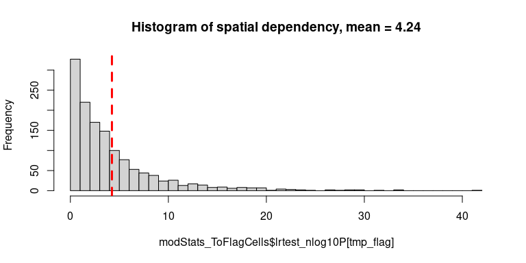

```r
# histogram for spatial dependency in all cells
tmp_flag <- which(!is.na(modStats_ToFlagCells$lrtest_nlog10P)) # exclude cells with too few transcript number
hist(modStats_ToFlagCells$lrtest_nlog10P[tmp_flag], breaks = "FD",
     main = paste0("Histogram of spatial dependency, mean = ",
                   round(mean(modStats_ToFlagCells$lrtest_nlog10P[tmp_flag]), 2)))
abline(v = mean(modStats_ToFlagCells$lrtest_nlog10P[tmp_flag]), col="red", lwd=3, lty=2)
```

The function above returns the statistics for evaluating each cell for spatial dependent model against null model. Based on the P value, `lrtest_Pr` or the negative log10 value `lrtest_nlog10P`, one can select for cells with strong spatial dependency in transcript score profile. Those cells are likely to contain contaminating transcripts for neighbor cells.

```r
# cutoff to flag for cells with strong spatial dependcy in transcript score profiles
flagCell_lrtest_cutoff  = 5

modStats_ToFlagCells[['flagged']] <- (modStats_ToFlagCells[['lrtest_nlog10P']] > flagCell_lrtest_cutoff )
flagged_cells <- modStats_ToFlagCells[['UMI_cellID']][modStats_ToFlagCells[['flagged']]]

message(sprintf("%d cells, %.4f of all evaluated cells, are flagged for resegmentation with lrtest_nlog10P > %.1f.",
                 length(flagged_cells), length(flagged_cells)/nrow(modStats_ToFlagCells), flagCell_lrtest_cutoff))
```

```
#> 373 cells, 0.2788 of all evaluated cells, are flagged for resegmentation with lrtest_nlog10P > 5.0.
```

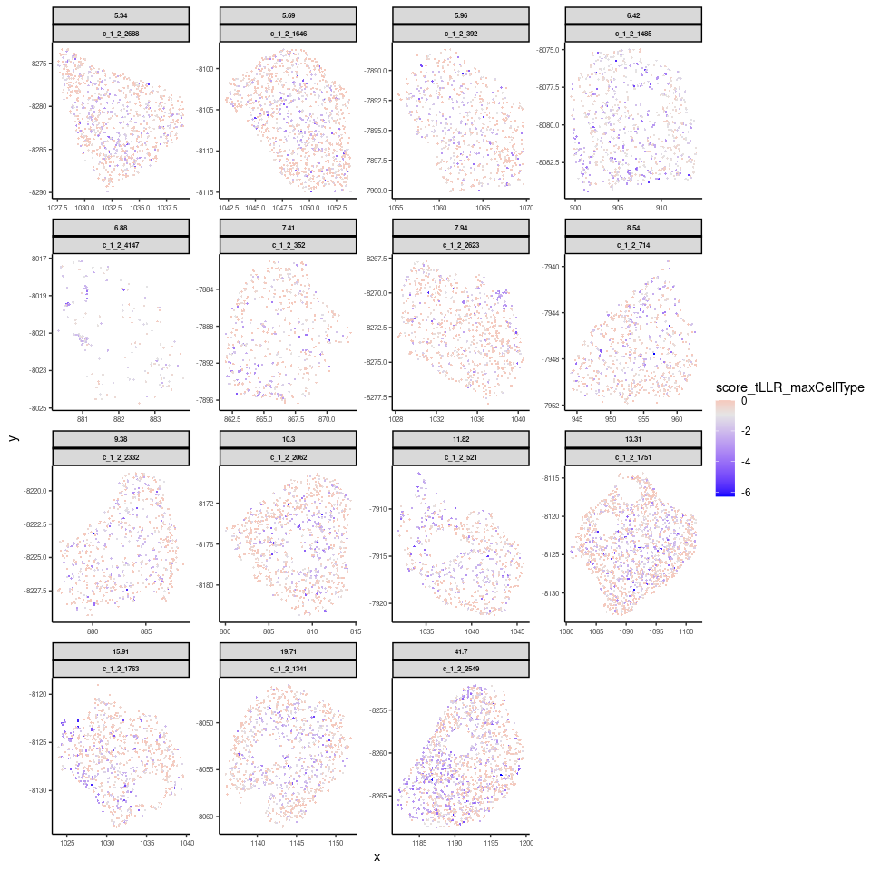

```r
# spatial plot some flagged cells with various degrees of spatial dependency in transcript profiles
rownames(modStats_ToFlagCells) <- modStats_ToFlagCells$UMI_cellID
cells_to_plot <- modStats_ToFlagCells[flagged_cells, 'lrtest_nlog10P']
names(cells_to_plot) <- flagged_cells
cells_to_plot <- cells_to_plot[order(cells_to_plot, decreasing = T)]
cells_to_plot <- cells_to_plot[seq(1, length(cells_to_plot), by = 25)]

plotSpatialScoreMultiCells(chosen_cells = names(cells_to_plot),
                           cell_labels = round(cells_to_plot, 2),
                           transcript_df = transcript_df,
                           cellID_coln = "UMI_cellID",
                           transID_coln = "UMI_transID",
                           score_coln = "score_tLLR_maxCellType",
                           spatLocs_colns = c("x","y"),
                           point_size = 0.5)
```

#### Identify wrongly segmented transcript groups

Under the assumption that the contamination from neighbor cells would result in patches of low-score transcript groups in space, we first separate the transcripts within each flagged cells into high and low score groups and then divide the transcripts of low score into different spatially connected groups assuming they might arise from different source cells in neighborhood.

```r
# cutoff of transcript score to separate between high and low score transcripts
svmClass_score_cutoff = -2

# a list of arguments to pass to `e1071::svm` function to define the strength of spatial connectivity
svm_args = list(kernel = "radial",
                scale = FALSE,
                gamma = 0.4)

groupDF_ToFlagTrans <- runTranscriptErrorDetection(chosen_cells = flagged_cells,
                                                   score_GeneMatrix = score_GeneMatrix,
                                                   transcript_df = transcript_df, # include column for transcript score under current cell segmentation
                                                   cellID_coln = "UMI_cellID",
                                                   transID_coln = "UMI_transID",
                                                   # column for transcript score in current cell segment
                                                   score_coln = 'score_tLLR_maxCellType',
                                                   spatLocs_colns = c("x","y","z"),
                                                   model_cutoff = 50,
                                                   score_cutoff = svmClass_score_cutoff,
                                                   svm_args = svm_args,
                                                   # maximum molecule-to-molecule distance within same transcript group
                                                   distance_cutoff = molecular_distance_cutoff,
                                                   # use "dbscan" method for spatial grouping of transcripts, alternative to use "delaunay"
                                                   groupTranscripts_method = "dbscan")
```

```
#> Run SVM in 3 Dimension.
#> Found 373 common cells and 960 common genes among chosen_cells, transcript_df, and score_GeneMatrix.
#> Warning in flag_bad_transcripts(chosen_cells = chosen_cells, score_GeneMatrix =
#> score_GeneMatrix, : Below model_cutoff = 50, skip 0 cells with fewer
#> transcripts. Move forward with remaining 373 cells.
#> Warning in flag_bad_transcripts(chosen_cells = chosen_cells, score_GeneMatrix =
#> score_GeneMatrix, : Skip 0 cells with all transcripts in same class given
#> `score_cutoff = -2`. Move forward with remaining 373 cells.
#> Remove 0 cells with raw transcript score all in same class based on cutoff -2.00 when running spatial SVM model.
#> Do spatial network analysis in 3 Dimension.
#> 10652 chosen_transcripts are found in common cells.
#> SVM spatial model further identified 17 cells with transcript score all in same class, exclude from transcript group analysis.
#> Found 960 common genes among transcript_df and score_GeneMatrix.
```

```r
head(groupDF_ToFlagTrans)
```

```
#>    UMI_transID UMI_cellID        x         y   z  target slide fov CellId
#> 1 t_1_2_100019 c_1_2_1280 1075.583 -8045.011 2.4    PSAP     1   2   1280
#> 2 t_1_2_100021 c_1_2_1311 1180.613 -8045.024 2.4    RXRB     1   2   1311
#> 3 t_1_2_100042 c_1_2_1311 1180.446 -8045.052 2.4  S100A6     1   2   1311
#> 4 t_1_2_100054 c_1_2_1280 1070.457 -8045.092 2.4    ABL2     1   2   1280
#> 5 t_1_2_100055 c_1_2_1297 1109.888 -8045.084 2.4 IL22RA1     1   2   1297
#> 6 t_1_2_100062 c_1_2_1280 1078.530 -8045.144 2.4    CD63     1   2   1280
#>   tLLR_maxCellType score_tLLR_maxCellType     DecVal SVM_class SVM_cell_type
#> 1                d            -0.84881774  1.0703177         1             d
#> 2                d            -0.83865972  0.9651801         1             d
#> 3                d             0.00000000  1.0000416         1             d
#> 4                d            -1.57303427  1.0000334         1             d
#> 5                f            -4.08493706 -0.8650251         1             f
#> 6                d            -0.01510279  1.0003084         1             d
#>   connect_group tmp_cellID group_maxCellType
#> 1             0 c_1_2_1280                 d
#> 2             0 c_1_2_1311                 d
#> 3             0 c_1_2_1311                 d
#> 4             0 c_1_2_1280                 d
#> 5             0 c_1_2_1297                 f
#> 6             0 c_1_2_1280                 d
```

The function above returns a transcript data.frame for the flagged cells with results in spatial-dependent score classification and spatial group ID assignment.

- `SVM_class` shows the transcript score classification, `0` for low score below cutoff, `1` for high score above cutoff; the corresponding decision values of svm model output are listed in `DecVal`.
  - One can use `SVM_class` to select all low-score transcript groups and then remove them from the original transcript data.frame all together. This approach effectively trims off the putative contaminating transcripts from current cell segmentation without more complex refinement.
- `connect_group` shows the spatial group ID assigned to each transcripts, while the corresponding cell types with maximum transcript scores under the given transcript groups are listed in `group_maxCellType`. `0` for transcript group with high score under the putative cell type of current cell segmentation.
- `tmp_cellID` is the column for new cell IDs with which each identified low-score transcript group is assigned with a unique new name to separate from its original cell. Transcript groups with high score would keep the same cell ID as the corresponding original cells.

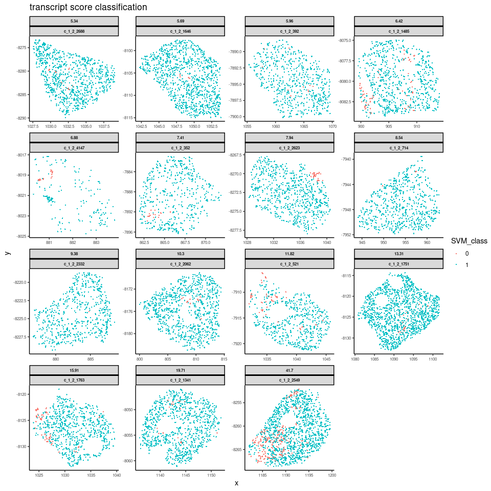

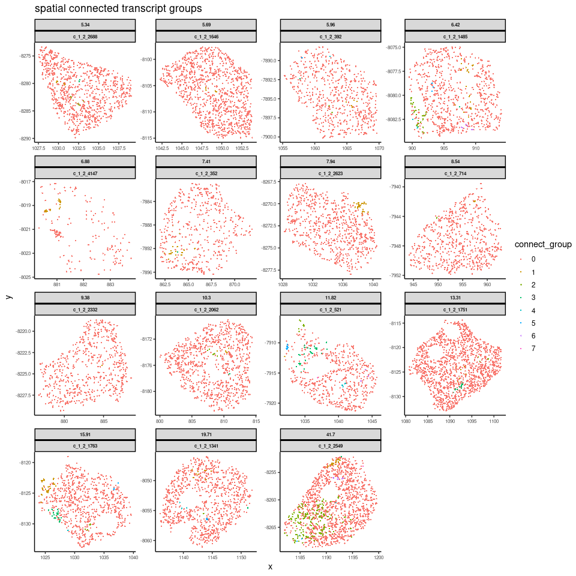

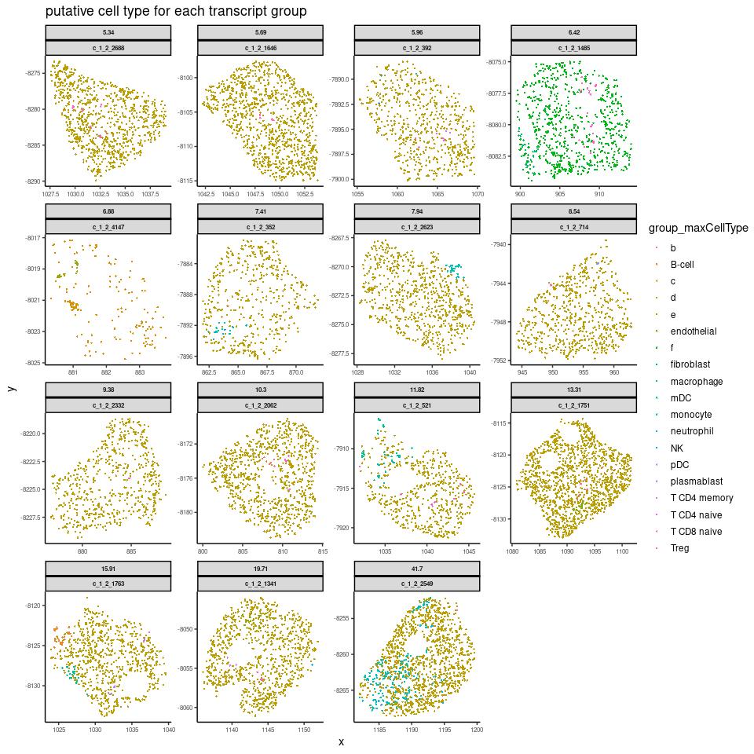

```r
# spatial plot for `SVM_class`, the high vs. low score classification of transcript groups in flagged cells
plotSpatialScoreMultiCells(chosen_cells = names(cells_to_plot),
                           cell_labels = round(cells_to_plot, 2),
                           transcript_df = groupDF_ToFlagTrans,
                           cellID_coln = "UMI_cellID",
                           transID_coln = "UMI_transID",
                           score_coln = "SVM_class",
                           spatLocs_colns = c("x","y"),
                           point_size = 0.5,
                           plot_discrete = T,
                           title = "transcript score classification")

# spatial plot for `connect_group`, the spatial group ID for transcripts within each cell
plotSpatialScoreMultiCells(chosen_cells = names(cells_to_plot),
                           cell_labels = round(cells_to_plot, 2),
                           transcript_df = groupDF_ToFlagTrans,
                           cellID_coln = "UMI_cellID",
                           transID_coln = "UMI_transID",
                           score_coln = "connect_group",
                           spatLocs_colns = c("x","y"),
                           point_size = 0.5,
                           plot_discrete = T,
                           title = "spatial connected transcript groups")

# spatial plot for `group_maxCellType`, the cell type with maximum score for each transcript group
plotSpatialScoreMultiCells(chosen_cells = names(cells_to_plot),
                           cell_labels = round(cells_to_plot, 2),
                           transcript_df = groupDF_ToFlagTrans,
                           cellID_coln = "UMI_cellID",
                           transID_coln = "UMI_transID",
                           score_coln = "group_maxCellType",
                           spatLocs_colns = c("x","y"),
                           point_size = 0.5,
                           plot_discrete = T,
                           title = "putative cell type for each transcript group")
```

#### Get ready for segmentation refinement

If one would like to perform more sophisticated cell segmentation refinement than simple trimming for all low-score transcript groups, one should update the original transcript data.frame with the new cell IDs and maximum cell types from the output of `runTranscriptErrorDetection()` function to keep those identified low-score transcript groups separated from their original cell segment assignment before further segmentation refinement.

```r
# update the transcript_df with flagged transcript_group
reSeg_ready_res <- prepResegDF(transcript_df = transcript_df,
                               groupDF_ToFlagTrans = groupDF_ToFlagTrans,
                               cellID_coln = "UMI_cellID",
                               transID_coln = "UMI_transID")

# `tmp_cellID` and `group_maxCellType` now contains info for all cells including the identified transcript groups
head(reSeg_ready_res[["reseg_transcript_df"]], n = 3L)
```

```
#>    UMI_transID UMI_cellID        x         y   z  target slide fov CellId
#> 1     t_1_2_10    c_1_2_5 914.8070 -7832.786 2.4 HLA-DRA     1   2      5
#> 2 t_1_2_100005 c_1_2_1270 841.7000 -8045.011 2.4   HLA-E     1   2   1270
#> 3 t_1_2_100006 c_1_2_1270 844.4609 -8045.006 2.4  TWIST1     1   2   1270
#>   tLLR_maxCellType score_tLLR_maxCellType connect_group tmp_cellID
#> 1                f             -0.4227132             0    c_1_2_5
#> 2                d             -0.5070020             0 c_1_2_1270
#> 3                d             -2.2769526             0 c_1_2_1270
#>   group_maxCellType
#> 1                 f
#> 2                 d
#> 3                 d
```

```r
# cells or group IDs for neighborhood evaluation
head(reSeg_ready_res[["groups_to_reseg"]])
```

```
#> [1] "c_1_2_1300_g1" "c_1_2_1340_g1" "c_1_2_1311_g1" "c_1_2_1376_g1"
#> [5] "c_1_2_1380_g1" "c_1_2_1356_g1"
```

#### Perform segmentation refinement

For more sophisticated cell segmentation refinement, we first evaluate the neighborhood environment of each low-score transcript groups in terms of their goodness of fit to nearby potential source cells, and then determine the corresponding resegmentation operation by comparing the neighborhood analysis results with the baseline data for each cell type derived from the original dataset. Lastly, we apply those resegmentation operations to the original transcript data.frame to get the refined segmentation outcomes. Each identified low-score transcript group may experience the following refinement operation: trimming (removing to extracellular space), splitting (keeping as new cell ID by itself), or merging (assigning same cell ID as that of neighboring cells/transcript groups of same cell type).

```r
finalRes <- runSegRefinement(
  score_GeneMatrix = score_GeneMatrix,
  chosen_cells = reSeg_ready_res[["groups_to_reseg"]],
  reseg_transcript_df = reSeg_ready_res[["reseg_transcript_df"]],
  reseg_cellID_coln = "tmp_cellID",
  reseg_celltype_coln = "group_maxCellType",
  transID_coln = "UMI_transID",
  transGene_coln = "target",
  transSpatLocs_coln = c('x','y','z'),
  score_baseline = score_baseline,
  lowerCutoff_transNum = lowerCutoff_transNum,
  higherCutoff_transNum= higherCutoff_transNum,
  neighbor_distance_xy = cellular_distance_cutoff,
  distance_cutoff = molecular_distance_cutoff,

  # apply spatial constraint on cell merging vs. splitting
  # default to "leidenCut" for decision based on Leiden clustering of transcript coordinates, alternative use "geometryDiff" for geometric analysis
  spatialMergeCheck_method = "leidenCut",
  # list of leiden clustering configuration to pass to `igraph::cluster_leiden()` function
  leiden_config = list(objective_function = "CPM",
                       resolution_parameter = 1,
                       beta = 0.01,
                       n_iterations = 200),
  # minimal percentage of transcripts shared membership between query cell and neighbor cells in leiden clustering results for a valid merging event
  cutoff_spatialMerge = 0.5,

  return_intermediates = TRUE, # flag to return intermediate outputs for neighborhood evaluation and resegmentation actions
  return_perCellData = TRUE,  # flag to return additional per cell data.frame and expression matrix
  includeAllRefGenes = FALSE # flag to include all genes in `score_GeneMatrix` in the returned `updated_perCellExprs` with missing genes of value
)
```

```
#> Perform leiden clustering at resolution_parameter = 1.000.
#> Create Delanay network when config$method is NULL.
#> Name the spatial network based on method as `Delaunay_network` when config$name is NULL.
#> Use neighbor_distance_xy = 20.0000 for searching of neighbor cells.
#> Use distance_cutoff = 2.0000 for defining direct neighbor cells based on molecule-to-molecule distance.
#> Use first 2D for searching cell neighborhood, but all 3 Dimension to identify direct neighbors based on molecular distance.
#> Found 2458 common cells and 960 common genes among transcript_df, cell_networkDT, and score_GeneMatrix.
#> 1083 chosen_cells are found in common cells.
#> Use `leidenCut` method to evaluate putative merging event in space.
#> Perform leiden clustering at resolution_parameter = 1.000.
#> A valid merging event must have query cell with 0.500 transcript shared same membership as neighbor cell of consistent cell type.
#> Run delanuay network in 3 Dimension.
#> Perform ledien clustering on 66 potential merging events.
#> (`c_1_2_1339_g4`, `c_1_2_1403_g6`) cell pair with all 7 transcripts in same z plane, run 2D network analysis.
#> (`c_1_2_1403_g6`, `c_1_2_1339_g4`) cell pair with all 7 transcripts in same z plane, run 2D network analysis.
#> (`c_1_2_921_g8`, `c_1_2_941_g1`) cell pair with all 15 transcripts in same z plane, run 2D network analysis.
#> (`c_1_2_941_g1`, `c_1_2_921_g8`) cell pair with all 15 transcripts in same z plane, run 2D network analysis.
#> Found 1084 common cells and 960 common genes among `names(reseg_full_converter)`, `transcript_df`, and `score_GeneMatrix`.
```

```r
# updated transcript data.frame with `updated_cellID` column reflecting the new transcript assignment to cells after refinement
# only includes transcripts that are intracellular in original segmentation and are genes in `score_GeneMatrix`
updated_transDF <- finalRes[["updated_transDF"]]
head(updated_transDF, n = 3L)
```

```
#>    UMI_transID UMI_cellID        x         y   z  target slide fov CellId
#> 1     t_1_2_10    c_1_2_5 914.8070 -7832.786 2.4 HLA-DRA     1   2      5
#> 2 t_1_2_100005 c_1_2_1270 841.7000 -8045.011 2.4   HLA-E     1   2   1270
#> 3 t_1_2_100006 c_1_2_1270 844.4609 -8045.006 2.4  TWIST1     1   2   1270
#>   tLLR_maxCellType score_tLLR_maxCellType connect_group tmp_cellID
#> 1                f             -0.4227132             0    c_1_2_5
#> 2                d             -0.5070020             0 c_1_2_1270
#> 3                d             -2.2769526             0 c_1_2_1270
#>   group_maxCellType updated_cellID updated_celltype score_updated_celltype
#> 1                 f        c_1_2_5                f             -0.4227132
#> 2                 d     c_1_2_1270                d             -0.5070020
#> 3                 d     c_1_2_1270                d             -2.2769526
```

```r
# updated per cell data.table after refinement, with resegmentation operation recorded in `reSeg_action`
updated_perCellDT <- finalRes[['updated_perCellDT']]
head(updated_perCellDT)
```

```
#>    updated_cellID updated_celltype         x         y        z reSeg_action
#> 1:     c_1_2_1000                d 1061.5538 -7993.376 2.691633         none
#> 2:     c_1_2_1001                f 1195.9138 -7993.106 4.192908         none
#> 3:     c_1_2_1009                d  807.5324 -7996.263 3.311172         none
#> 4:     c_1_2_1010                d  928.8692 -7996.915 3.523333         none
#> 5:     c_1_2_1011                d 1135.7938 -7996.114 2.759471         none
#> 6:     c_1_2_1012                d 1146.3545 -7996.048 2.354226         trim
```

```r
table(updated_perCellDT[['reSeg_action']])
```

```
#>
#> merge_or_flagged              new             none             trim
#>                4                3             1017              354
```

`runSegRefinement()` function returns a list of outputs with updated cell segmentation that could be used in further single cell analysis.

variable

description

`updated_transDF`

the updated transcript_df with `updated_cellID` and `updated_celltype` columns reflecting the new segmentation outcomes

`neighborhoodDF_ToReseg`

data.frame for neighborhood environment of low-score transcript groups, output of `neighborhood_for_resegment_spatstat()` function, return when `return_intermediates = TRUE`

`reseg_actions`

*list of 4 elements describing how the resegmenation would be performed on `reseg_transcript_df` by the group assignment of transcripts listed in `reseg_cellID_coln`, return when `return_intermediates = TRUE`*

- `cells_to_discard`: a vector of cell ID that should be discarded during resegmentation.
- `cells_to_update`: a named vector of cell ID whether the cell_ID in name would be replaced with new cell_ID in value.
- `cells_to_keep`: a vector of cell ID that should be kept as it is.
- `reseg_full_converter`: a single named vector of cell ID to update the original cell ID, assign `NA` for `cells_to_discard`.

`updated_perCellDT`

per cell data.table with mean spatial coordinates, new cell type and resegmentation action after resegmentation, return when `return_perCellData = TRUE`

`updated_perCellExprs`

gene x cell count sparse matrix for updated transcript data.frame after resegmentation, return when `return_perCellData = TRUE`

##### Visualize example resegmentation outcomes

Let’s check on a few cells which got changed by the segmentation refinement process.

```r
# choose example cells got segmentation refinement operations of various kinds
trimmed_cells_to_plot <- updated_perCellDT[reSeg_action == "trim" & updated_cellID %in% names(cells_to_plot), updated_cellID]
changes_to_plot <- updated_perCellDT[!reSeg_action %in% c("none", "trim") | updated_cellID %in% trimmed_cells_to_plot , .SD, .SDcols = c('updated_cellID', 'reSeg_action')]

changes_to_plot <- merge(changes_to_plot,
                         unique(updated_transDF[updated_transDF[['updated_cellID']] %in% changes_to_plot[['updated_cellID']], c('UMI_cellID', 'updated_cellID')]))
changes_to_plot[, oriCellNum_in_newCell := .N, by = updated_cellID ]
changes_to_plot[, newCellNum_from_oriCell := .N, by = UMI_cellID]

## segmentation changes for the selected cells with original cell_ID in `UMI_cellID` column
print(changes_to_plot[order(reSeg_action, - newCellNum_from_oriCell), ])
```

```
#>     updated_cellID     reSeg_action UMI_cellID oriCellNum_in_newCell
#>  1:  c_1_2_1481_g5 merge_or_flagged c_1_2_1493                     2
#>  2:  c_1_2_1481_g5 merge_or_flagged c_1_2_1481                     2
#>  3:     c_1_2_1655 merge_or_flagged c_1_2_1655                     2
#>  4:     c_1_2_1655 merge_or_flagged c_1_2_1668                     2
#>  5:     c_1_2_1683 merge_or_flagged c_1_2_1683                     2
#>  6:     c_1_2_1683 merge_or_flagged c_1_2_1732                     2
#>  7:     c_1_2_2243 merge_or_flagged c_1_2_2243                     1
#>  8:  c_1_2_2549_g2              new c_1_2_2549                     1
#>  9:  c_1_2_1502_g1              new c_1_2_1502                     1
#> 10:  c_1_2_1758_g1              new c_1_2_1758                     1
#> 11:     c_1_2_2549             trim c_1_2_2549                     1
#> 12:     c_1_2_1341             trim c_1_2_1341                     1
#> 13:     c_1_2_1485             trim c_1_2_1485                     1
#> 14:     c_1_2_1646             trim c_1_2_1646                     1
```

[output cut: 39 more lines]

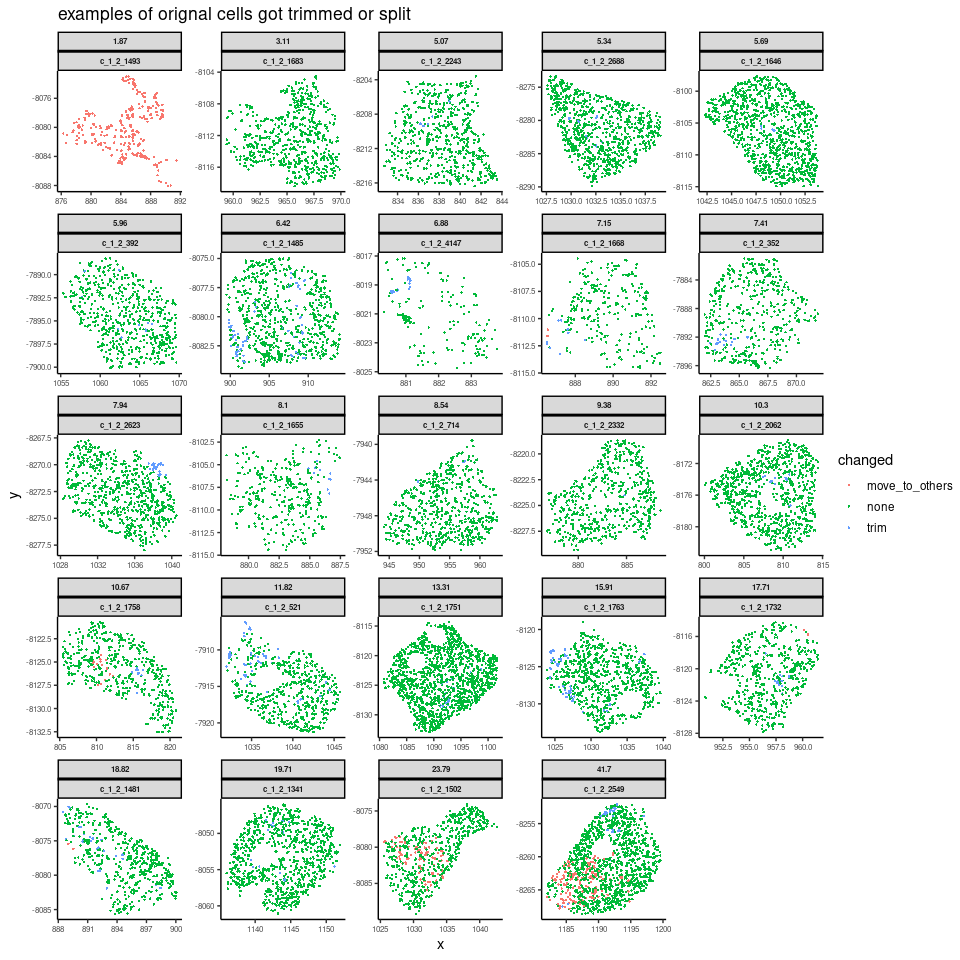

```r
# get all transcript in the source cells for plotting
transDF_to_plot <- merge(
  reSeg_ready_res[["reseg_transcript_df"]][reSeg_ready_res[["reseg_transcript_df"]][["UMI_cellID"]] %in% changes_to_plot[['UMI_cellID']], ],
  updated_transDF[updated_transDF[["UMI_cellID"]] %in% changes_to_plot[['UMI_cellID']], ],
  all.x = T)

# label changed with respect to original cell segmentation
trim_idx <- which(is.na(transDF_to_plot[['updated_cellID']]))
alter_idx <- which(transDF_to_plot[['updated_cellID']] != transDF_to_plot[['UMI_cellID']])

transDF_to_plot[['changed']] <- 'none'
transDF_to_plot[['changed']][alter_idx] <- 'move_to_others'
transDF_to_plot[['changed']][trim_idx] <- 'trim'

# spatial plot for modification on original source cells
cells_to_plot2 <- unique(changes_to_plot[['UMI_cellID']])
plotSpatialScoreMultiCells(chosen_cells = cells_to_plot2,
                           cell_labels = round(modStats_ToFlagCells[cells_to_plot2, 'lrtest_nlog10P'], 2),
                           transcript_df = transDF_to_plot,
                           cellID_coln = "UMI_cellID",
                           transID_coln = "UMI_transID",
                           score_coln = "changed",
                           spatLocs_colns = c("x","y"),
                           point_size = 0.5,
                           plot_discrete = T,
                           title = "examples of orignal cells got trimmed or split")
```

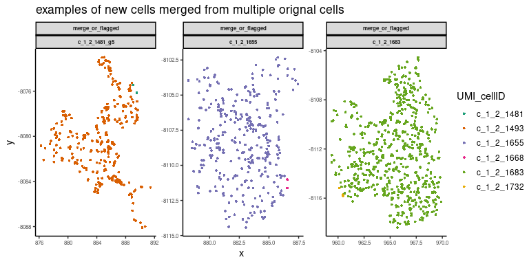

```r
# spatial plot for new cells merged from multiple original cells
cells_to_plot2 <- changes_to_plot[oriCellNum_in_newCell >1,]
fig <- plotSpatialScoreMultiCells(chosen_cells = cells_to_plot2[['updated_cellID']],
                                  cell_labels = cells_to_plot2[['reSeg_action']],
                                  transcript_df = transDF_to_plot,
                                  cellID_coln = "updated_cellID",
                                  transID_coln = "UMI_transID",
                                  score_coln = "UMI_cellID",
                                  spatLocs_colns = c("x","y"),
                                  point_size = 1,
                                  plot_discrete = T,
                                  title = "examples of new cells merged from multiple orignal cells")
fig <- fig + ggplot2::scale_color_brewer(palette = "Dark2")
print(fig)
```